# Coding Assignment 3

Team 4: Marko Kuzet, Anthony Morel, Candice Bloom, Melissa Fuentes

Due: 2021-12-09 23:59

A Florida health insurance company wants to predict annual claims for individual clients. The company pulls a random sample of 50 customers. The owner wishes to charge an actuarially fair premium to ensure a normal rate of return. The owner collects all of their current customer’s health care expenses from the last year and compares them with what is known about each customer’s plan.

The data on the 50 customers in the sample is as follows:

- Charges: Total medical expenses for a particular insurance plan (in dollars)
- Age: Age of the primary beneficiary
- BMI: Primary beneficiary’s body mass index (kg/m2)
- Female: Primary beneficiary’s birth sex (0 = Male, 1 = Female)
- Children: Number of children covered by health insurance plan (includes other dependents as well)
- Smoker: Indicator if primary beneficiary is a smoker (0 = non-smoker, 1 = smoker)
- Cities: Dummy variables for each city with the default being Sanford

Answer the following questions using complete sentences and attach all output, plots, etc. within this report.

## Question 1

Randomly select three observations from the sample and exclude from all modeling (i.e. n=47). Provide the summary statistics (min, max, std, mean, median) of the quantitative variables for the 47 observations.

```r
set.seed(123456)
index <- sample(seq_len(nrow(insurance)), size = 3)

train <- insurance[-index,]
test <- insurance[index,]


summary(train)[,c(1:3,5)]
```

```
##     Charges           Age             BMI           Children
##  Min.   : 1719   Min.   :18.00   Min.   :17.29   Min.   :0.000
##  1st Qu.: 6899   1st Qu.:29.00   1st Qu.:28.05   1st Qu.:0.000
##  Median :11882   Median :41.00   Median :31.46   Median :1.000
##  Mean   :14610   Mean   :39.66   Mean   :31.74   Mean   :1.234
##  3rd Qu.:18756   3rd Qu.:49.00   3rd Qu.:35.62   3rd Qu.:2.000
##  Max.   :44501   Max.   :63.00   Max.   :52.58   Max.   :5.000
```

```r
sd(insurance$Charges)
```

```
## [1] 11983.26
```

```r
sd(insurance$Age)
```

```
## [1] 13.36778
```

```r
sd(insurance$BMI)
```

```
## [1] 6.474533
```

```r
sd(insurance$Children)
```

```
## [1] 1.229568
```

## Question 2

Provide the correlation between all quantitative variables

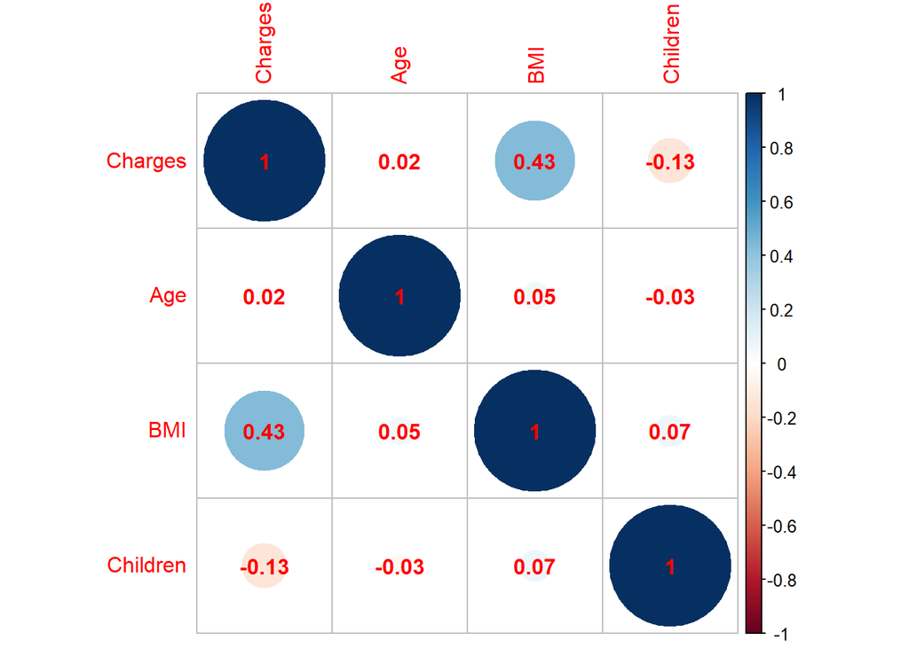

```r
corrplot(cor(train[,c(1:3,5)]), addCoef.col = "red")
```

The corrplot shows that the variables with the highest correlation are Charges and BMI with a value of 0.43, which is a positively weak correlation, higher than the rest of the quantitative variables.

## Question 3

Run a regression that includes all independent variables in the data table. Does the model above violate any of the Gauss-Markov assumptions? If so, what are they and what is the solution for correcting?

```r
model_1 <- lm(Charges ~., data = train )
summary(model_1)
```

```
##
## Call:
## lm(formula = Charges ~ ., data = train)
##
## Residuals:
##    Min     1Q Median     3Q    Max
## -12326  -2526  -1380   3509  14269
##
## Coefficients:
##                Estimate Std. Error t value Pr(>|t|)
## (Intercept)   -27417.40    5519.58  -4.967 1.47e-05 ***
## Age              246.63      68.77   3.586 0.000943 ***
## BMI              804.54     135.74   5.927 7.16e-07 ***
## Female          1442.40    1749.47   0.824 0.414814
## Children         276.68     769.61   0.360 0.721201
## Smoker         19919.50    2242.32   8.883 8.24e-11 ***
## WinterSprings   4068.13    2532.89   1.606 0.116526
## WinterPark      1517.17    2507.70   0.605 0.548772
## Oviedo         -1534.97    2574.60  -0.596 0.554578
## ---
## Signif. codes:  0 '***' 0.001 '**' 0.01 '*' 0.05 '.' 0.1 ' ' 1
##
## Residual standard error: 5664 on 38 degrees of freedom
## Multiple R-squared:  0.7886, Adjusted R-squared:  0.7441
## F-statistic: 17.72 on 8 and 38 DF,  p-value: 1.178e-10
```

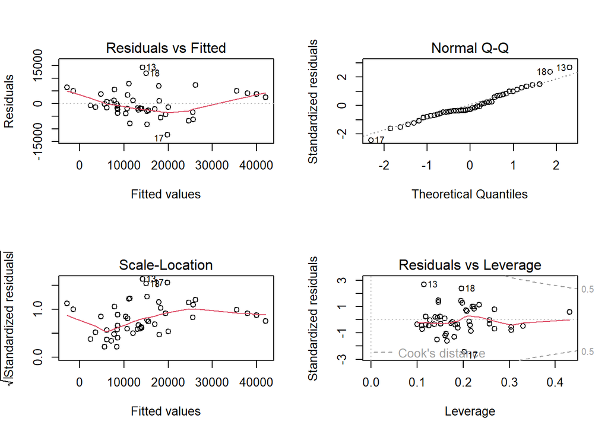

```r
par(mfrow=c(2,2))
plot(model_1)
```

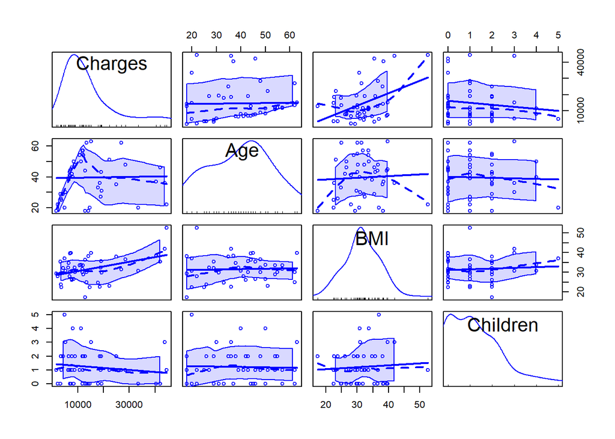

```r
scatterplotMatrix(train[,c(1:3,5)])
```

From here you can see some non-linear relationships and non-normally distributed variables.

## Question 4

Implement the solutions from question 3, such as data transformation, along with any other changes you wish. Use the sample data run a new regression. How have the fit measures changed? How have the signs and significance of the coefficients changed?

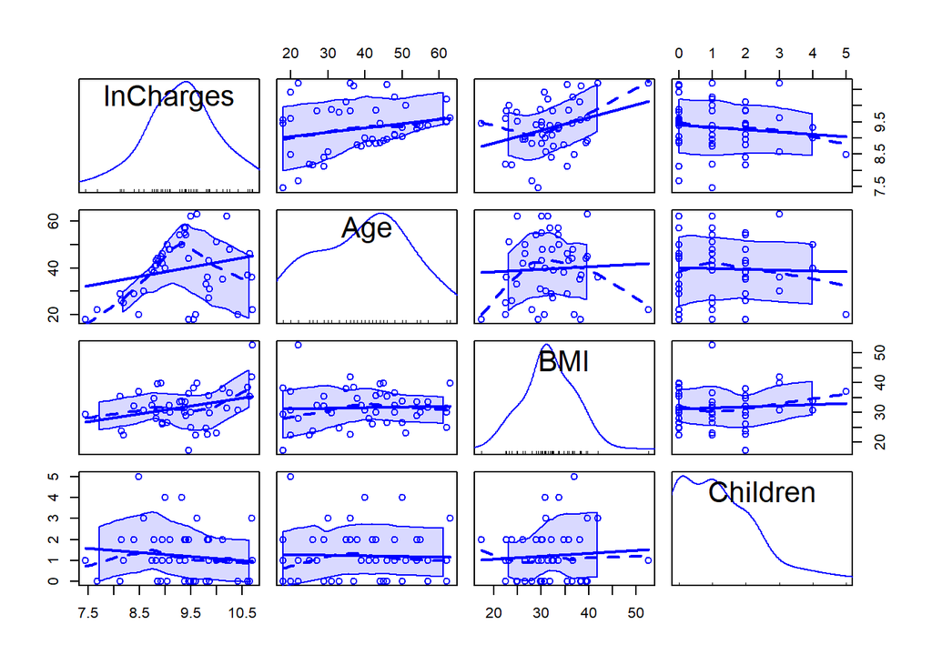

```r
#The following transformations were applied due to the nature of the independent variables:

#For Charges, we decided to apply log in order to fix the distribution.
train$lnCharges <- log(train$Charges)

#with only transforming Charges we have
scatterplotMatrix(train[,c(10,2,3,5)])
```

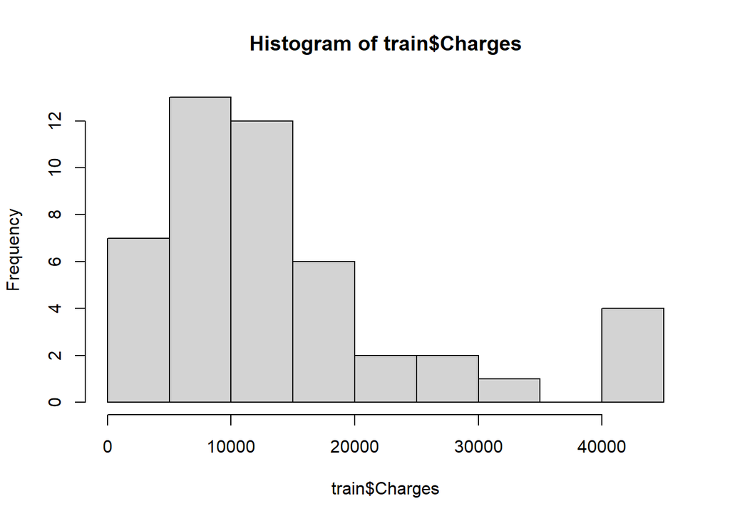

```r
#with only Charges transformation we have these two histograms of a before and after:

hist(train$Charges)
```

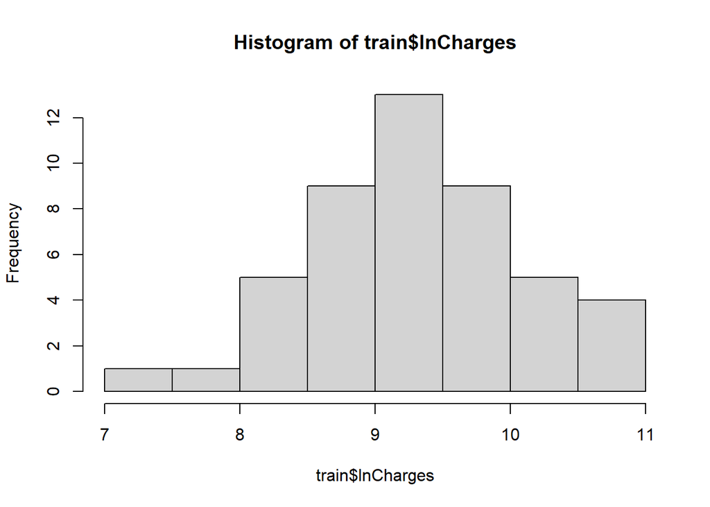

```r
hist(train$lnCharges)
```

```r
#For both both Age and BMI we can assume the quadratic nature of the variables:
#As far as AGE, the younger we are the more medical attention we would need, if we are analyzing an adult at a mature age they normally would not need much medical attention, and someone who is at an advanced age (elderly) would probably need more medical attention.


train$AgeSq <- train$Age^2

train$lnAge <- log(train$Age)

#BMI would almost work the same way, the less BMI the average human has the more likely they will need more medical attention (ANOREXIC), if we are observing an average adult at a normal BMI the less medical attention needed, and someone who is at a higher BMI would probably need more medical attention (OBSESITY).


train$BMISq <- train$BMI^2

train$lnBMI <- log(train$BMI)
```

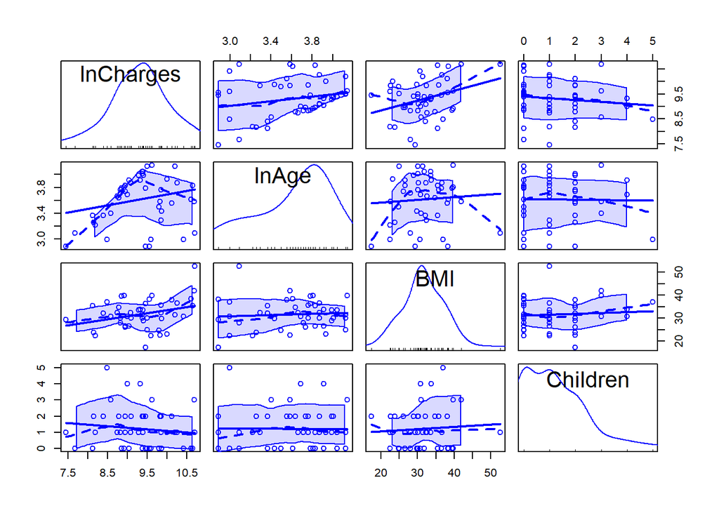

```r
#Applying transformations

#with transforming every variable we get the following scatter plots:

#lnage
scatterplotMatrix(train[,c(10,12,3,5)])
```

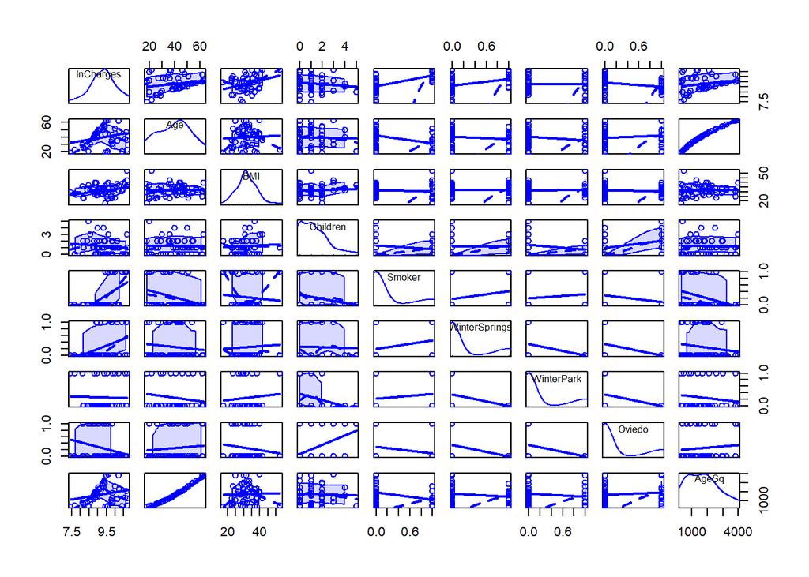

```r
#sqage
#with transforming every variable we get:
scatterplotMatrix(train[,c(10,2,3,5:9,11)])
```

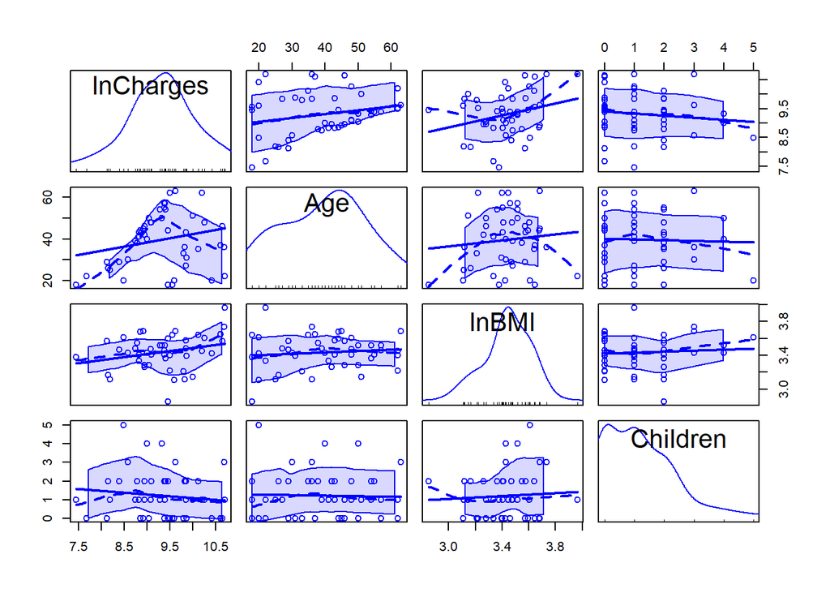

```r
#lnBMI
scatterplotMatrix(train[,c(10,2,14,5)])
```

```r
#Creating different models with our transformations:

#Model of lnCharges
model_lncharges <-lm(lnCharges ~., data = train[,c(10,2:9)])
summary(model_lncharges)
```

```
##
## Call:
## lm(formula = lnCharges ~ ., data = train[, c(10, 2:9)])
##
## Residuals:
##      Min       1Q   Median       3Q      Max
## -0.74143 -0.18760 -0.05136  0.15336  0.95669
##
## Coefficients:
##                Estimate Std. Error t value Pr(>|t|)
## (Intercept)    6.419984   0.407812  15.743  < 2e-16 ***
## Age            0.028910   0.005081   5.690 1.52e-06 ***
## BMI            0.041009   0.010029   4.089 0.000217 ***
## Female         0.162222   0.129259   1.255 0.217136
## Children       0.026658   0.056862   0.469 0.641871
## Smoker         1.364493   0.165673   8.236 5.60e-10 ***
## WinterSprings  0.303892   0.187141   1.624 0.112672
## WinterPark    -0.072829   0.185280  -0.393 0.696459
## Oviedo        -0.152641   0.190223  -0.802 0.427294
## ---
## Signif. codes:  0 '***' 0.001 '**' 0.01 '*' 0.05 '.' 0.1 ' ' 1
##
## Residual standard error: 0.4185 on 38 degrees of freedom
## Multiple R-squared:  0.7564, Adjusted R-squared:  0.7051
## F-statistic: 14.75 on 8 and 38 DF,  p-value: 1.561e-09
```

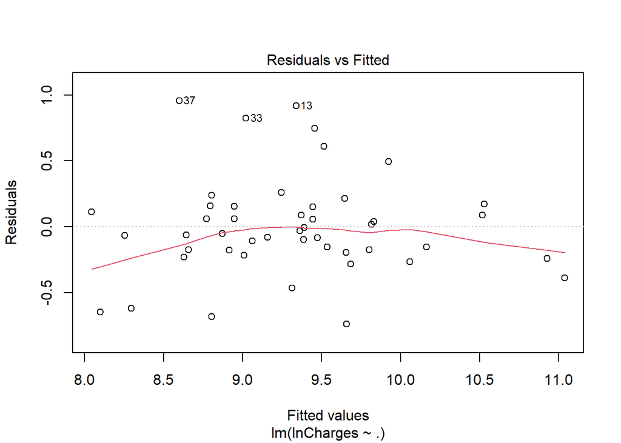

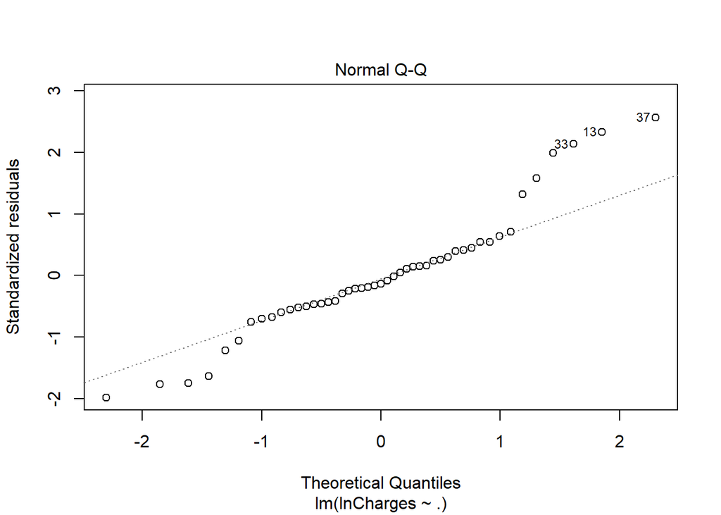

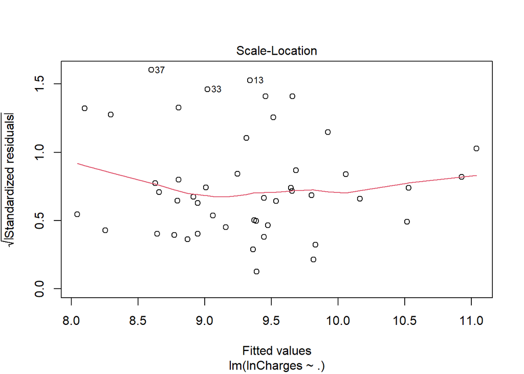

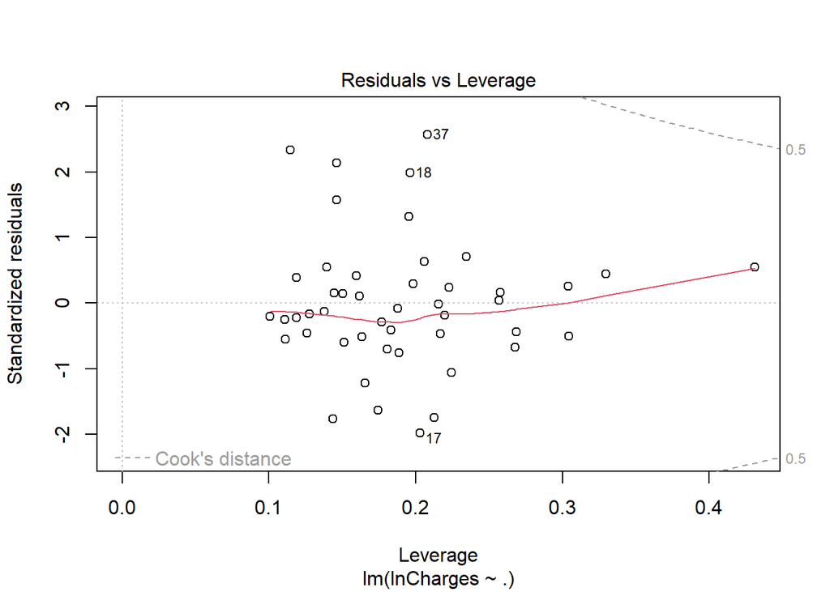

```r
plot(model_lncharges)
```

```r
#Log of Age
model_lnAge <-lm(lnCharges ~., data = train[,c(10,12,3:9)])
summary(model_lnAge)
```

```
##
## Call:
## lm(formula = lnCharges ~ ., data = train[, c(10, 12, 3:9)])
##
## Residuals:
##      Min       1Q   Median       3Q      Max
## -0.76759 -0.20996 -0.03113  0.18114  1.02938
##
## Coefficients:
##               Estimate Std. Error t value Pr(>|t|)
## (Intercept)    4.11544    0.77943   5.280 5.52e-06 ***
## lnAge          0.97077    0.18842   5.152 8.25e-06 ***
## BMI            0.04010    0.01049   3.823 0.000475 ***
## Female         0.14205    0.13454   1.056 0.297713
## Children       0.02152    0.05930   0.363 0.718717
## Smoker         1.33688    0.17230   7.759 2.37e-09 ***
## WinterSprings  0.27634    0.19513   1.416 0.164878
## WinterPark    -0.07151    0.19374  -0.369 0.714091
## Oviedo        -0.15994    0.19870  -0.805 0.425874
## ---
## Signif. codes:  0 '***' 0.001 '**' 0.01 '*' 0.05 '.' 0.1 ' ' 1
##
## Residual standard error: 0.437 on 38 degrees of freedom
## Multiple R-squared:  0.7344, Adjusted R-squared:  0.6784
## F-statistic: 13.13 on 8 and 38 DF,  p-value: 7.426e-09
```

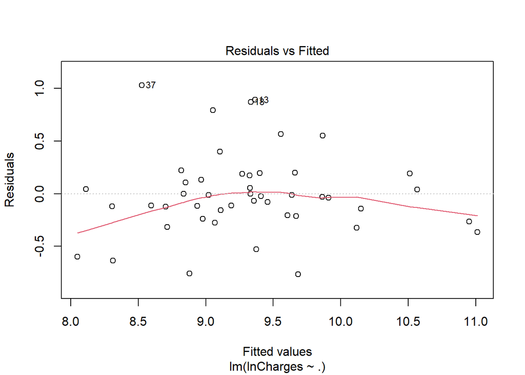

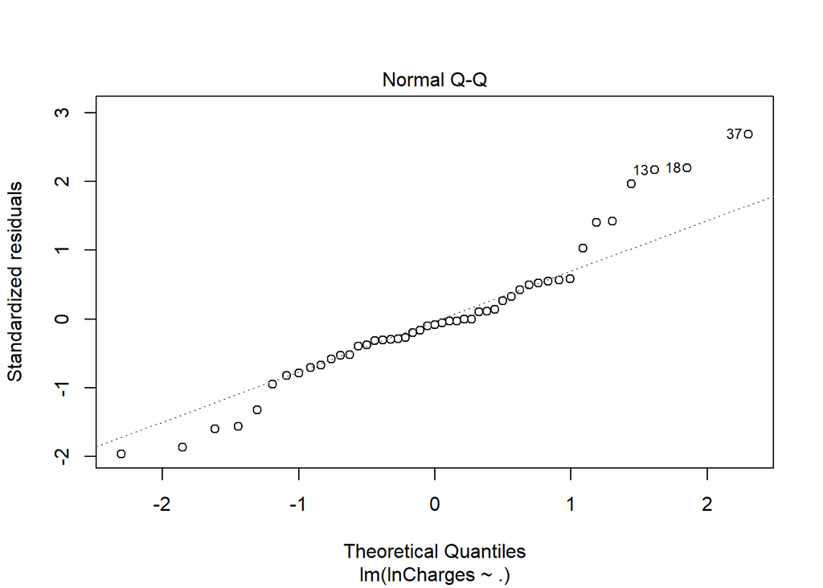

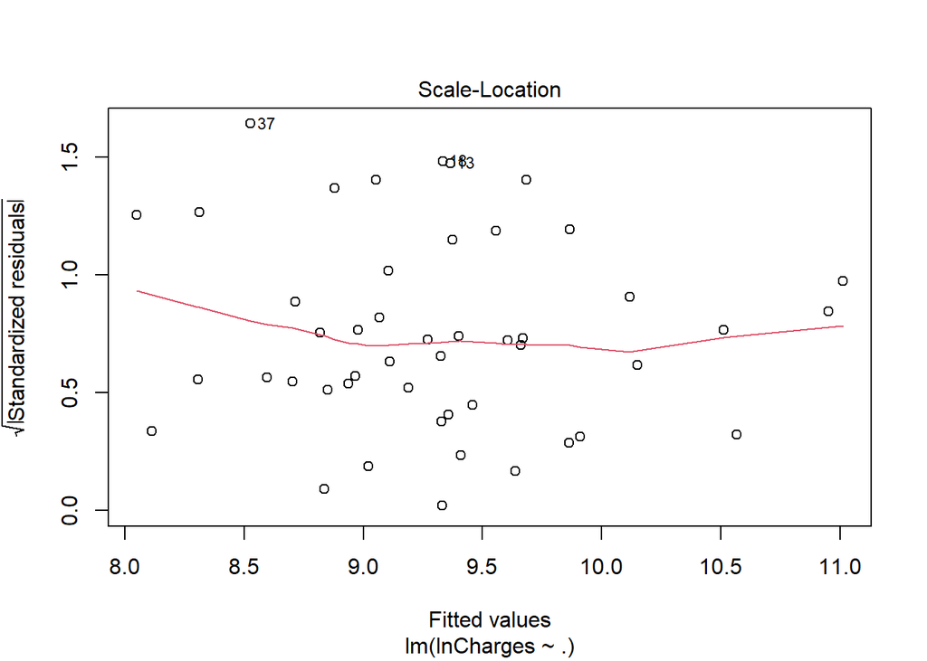

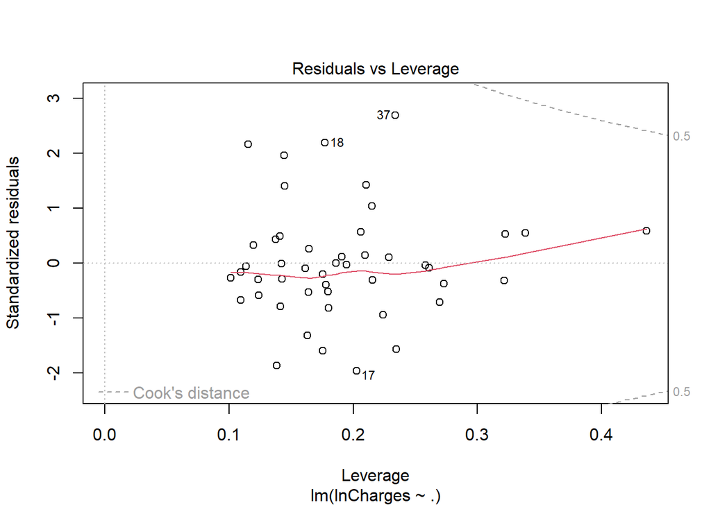

```r
plot(model_lnAge)
```

```r
#Age and Age^2
model_Agesquared <-lm(lnCharges ~., data = train[,c(10,2,3:9,11)])
summary(model_Agesquared)
```

```
##
## Call:
## lm(formula = lnCharges ~ ., data = train[, c(10, 2, 3:9, 11)])
##
## Residuals:
##      Min       1Q   Median       3Q      Max
## -0.73952 -0.19956 -0.03338  0.13967  0.96937
##
## Coefficients:
##                 Estimate Std. Error t value Pr(>|t|)
## (Intercept)    6.9548310  0.6039392  11.516 8.55e-14 ***
## Age           -0.0050456  0.0288581  -0.175 0.862156
## BMI            0.0422522  0.0100269   4.214 0.000155 ***
## Female         0.1721024  0.1288024   1.336 0.189652
## Children       0.0290478  0.0565796   0.513 0.610726
## Smoker         1.3704449  0.1648225   8.315 5.44e-10 ***
## WinterSprings  0.3356101  0.1879785   1.785 0.082402 .
## WinterPark    -0.0848114  0.1845175  -0.460 0.648465
## Oviedo        -0.1437436  0.1893068  -0.759 0.452474
## AgeSq          0.0004323  0.0003618   1.195 0.239652
## ---
## Signif. codes:  0 '***' 0.001 '**' 0.01 '*' 0.05 '.' 0.1 ' ' 1
##
## Residual standard error: 0.4161 on 37 degrees of freedom
## Multiple R-squared:  0.7654, Adjusted R-squared:  0.7083
## F-statistic: 13.41 on 9 and 37 DF,  p-value: 3.242e-09
```

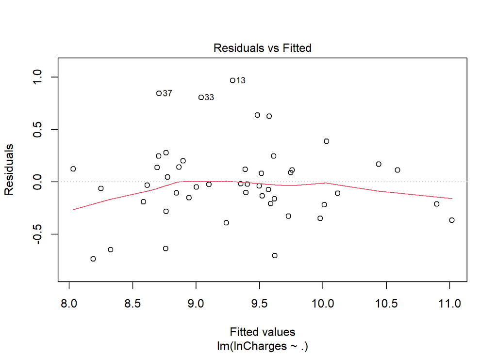

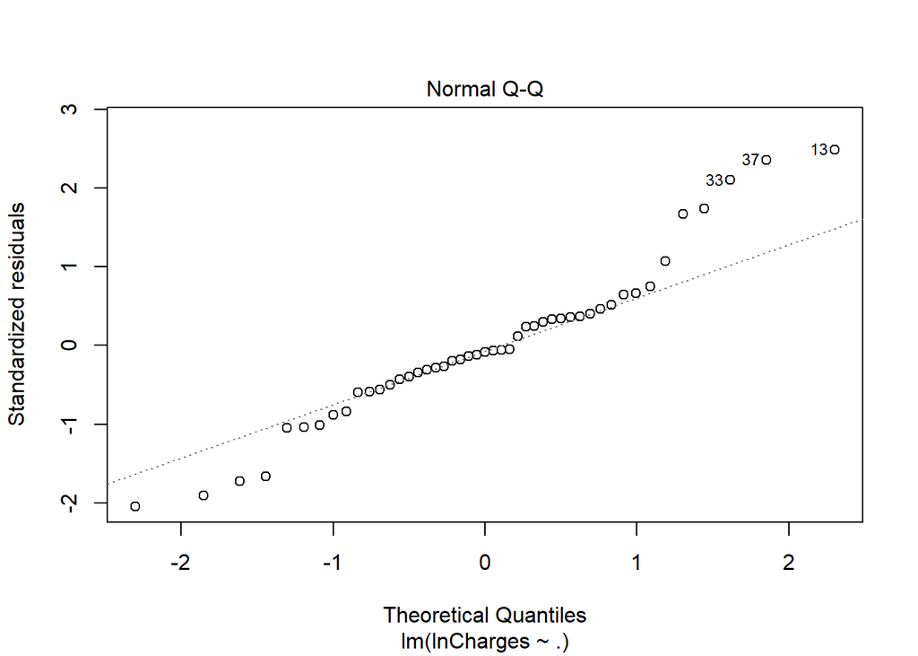

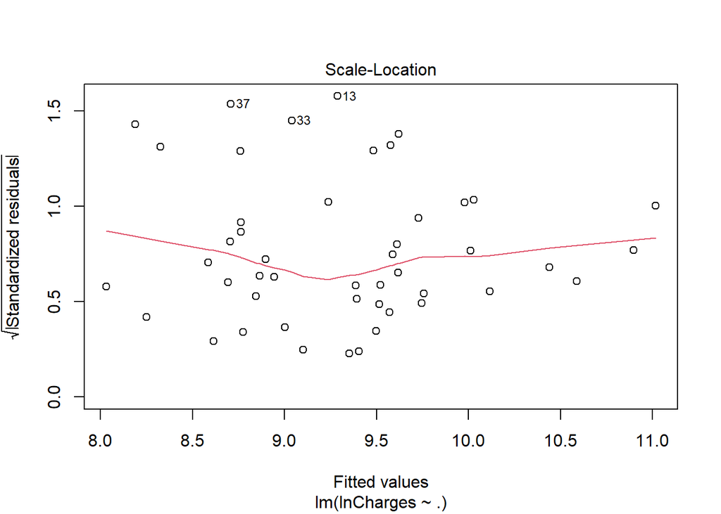

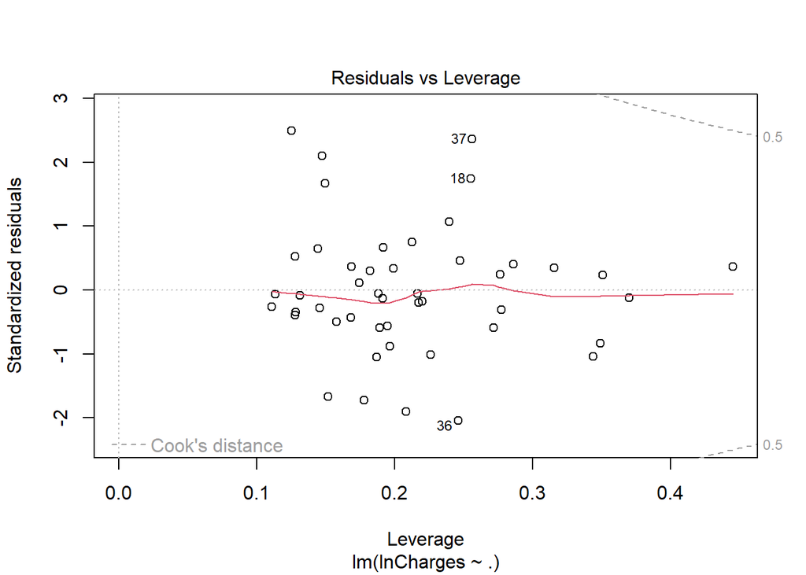

```r
plot(model_Agesquared)
```

```r
#Log of BMI
model_lnBMI <-lm(lnCharges ~., data = train[,c(10,2,14,4:9)])
summary(model_lnBMI)
```

```
##
## Call:
## lm(formula = lnCharges ~ ., data = train[, c(10, 2, 14, 4:9)])
##
## Residuals:
##      Min       1Q   Median       3Q      Max
## -0.71088 -0.18777 -0.03823  0.15445  0.96650
##
## Coefficients:
##                Estimate Std. Error t value Pr(>|t|)
## (Intercept)    3.364654   1.106012   3.042 0.004244 **
## Age            0.028216   0.005136   5.494 2.81e-06 ***
## lnBMI          1.272594   0.319380   3.985 0.000296 ***
## Female         0.150461   0.130314   1.155 0.255463
## Children       0.030309   0.057213   0.530 0.599354
## Smoker         1.407405   0.168294   8.363 3.83e-10 ***
## WinterSprings  0.304035   0.188620   1.612 0.115262
## WinterPark    -0.071747   0.186738  -0.384 0.702963
## Oviedo        -0.152767   0.191729  -0.797 0.430525
## ---
## Signif. codes:  0 '***' 0.001 '**' 0.01 '*' 0.05 '.' 0.1 ' ' 1
##
## Residual standard error: 0.4217 on 38 degrees of freedom
## Multiple R-squared:  0.7525, Adjusted R-squared:  0.7004
## F-statistic: 14.44 on 8 and 38 DF,  p-value: 2.067e-09
```

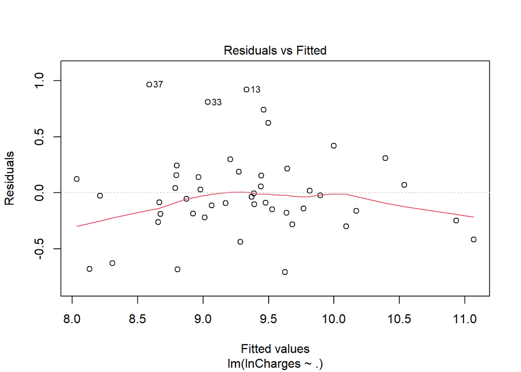

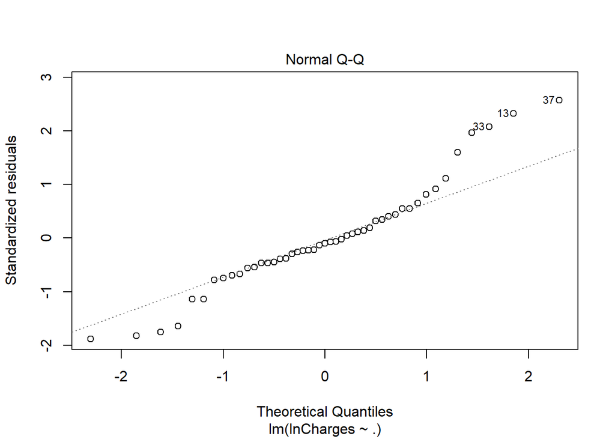

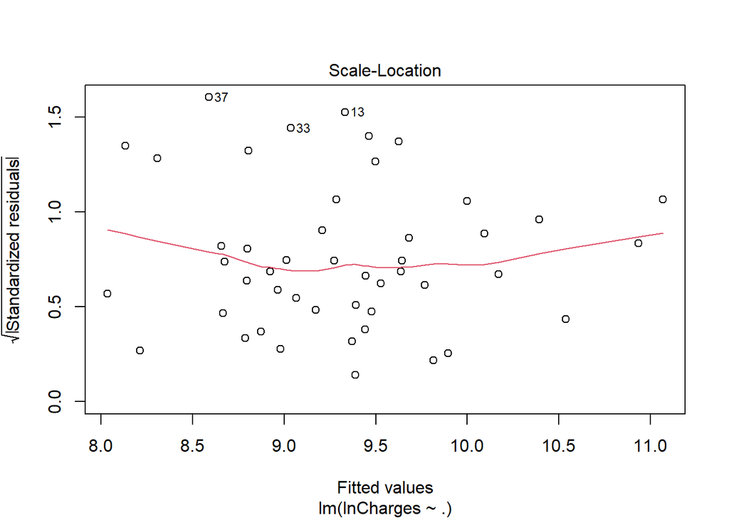

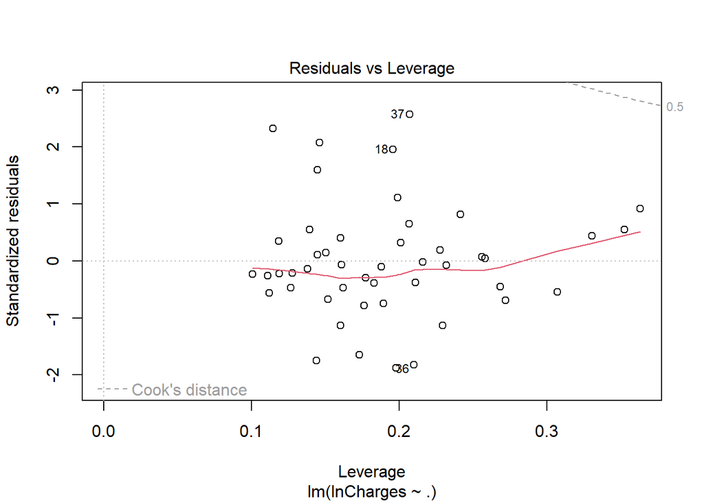

```r
plot(model_lnBMI)
```

```r
#BMI and BMI^2
model_BMIsquared <-lm(lnCharges ~., data = train[,c(10,2,3:9,13)])
summary(model_BMIsquared)
```

```
##
## Call:
## lm(formula = lnCharges ~ ., data = train[, c(10, 2, 3:9, 13)])
##
## Residuals:
##      Min       1Q   Median       3Q      Max
## -0.74947 -0.19116 -0.05424  0.12845  0.96185
##
## Coefficients:
##                 Estimate Std. Error t value Pr(>|t|)
## (Intercept)    6.7592772  1.2493187   5.410 3.95e-06 ***
## Age            0.0292863  0.0053072   5.518 2.82e-06 ***
## BMI            0.0192471  0.0763072   0.252    0.802
## Female         0.1695913  0.1333304   1.272    0.211
## Children       0.0257189  0.0576534   0.446    0.658
## Smoker         1.3406144  0.1871182   7.165 1.71e-08 ***
## WinterSprings  0.3065802  0.1896717   1.616    0.115
## WinterPark    -0.0750033  0.1877097  -0.400    0.692
## Oviedo        -0.1553793  0.1927964  -0.806    0.425
## BMISq          0.0003253  0.0011304   0.288    0.775
## ---
## Signif. codes:  0 '***' 0.001 '**' 0.01 '*' 0.05 '.' 0.1 ' ' 1
##
## Residual standard error: 0.4236 on 37 degrees of freedom
## Multiple R-squared:  0.7569, Adjusted R-squared:  0.6978
## F-statistic:  12.8 on 9 and 37 DF,  p-value: 6.044e-09
```

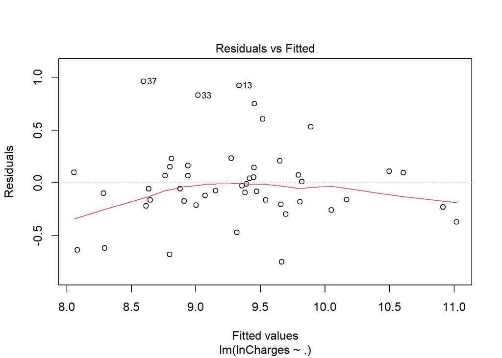

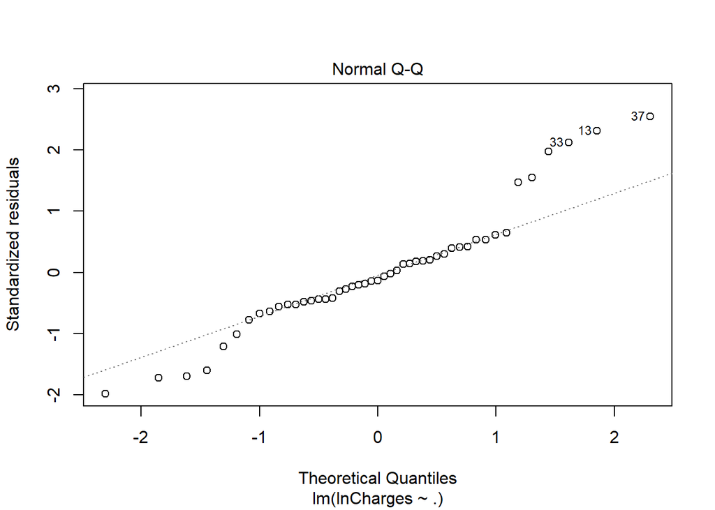

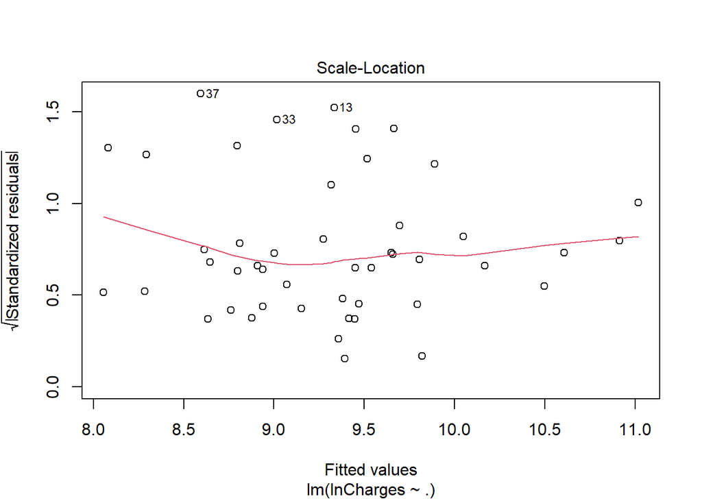

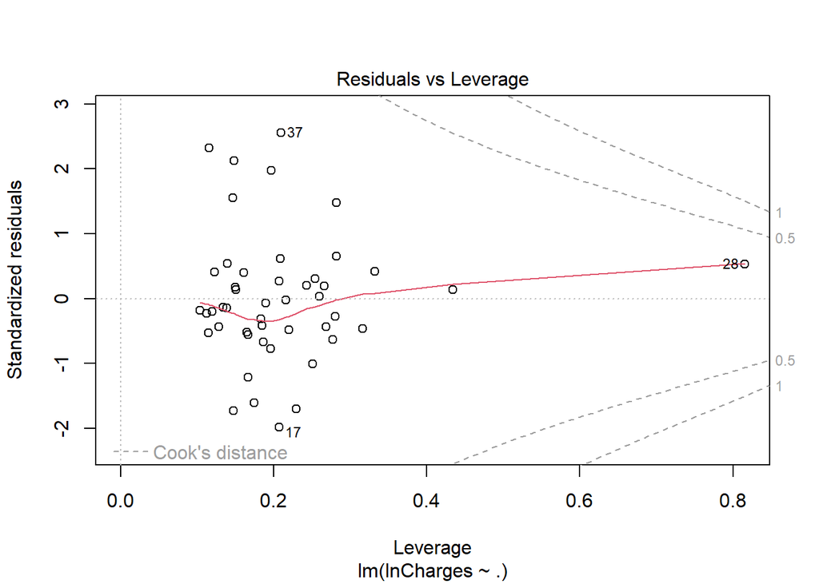

```r
plot(model_BMIsquared)
```

## Question 5

Use the 3 withheld observations and calculate the performance measures for your best two models. Which is the better model? (remember that “better” depends on whether your outlook is short or long run)

```r
test$lncharges <-log(test$Charges)
test$lnAge <- log(test$Age)
test$AgeSq <- test$Age^2
test$lnBMI <- log(test$BMI)
test$BMISq <- test$BMI^2




#bad model
test$model_model_1_pred <- predict(model_1, newdata = test)
#model 1
test$model_lncharges_pred <- predict(model_lncharges, newdata = test) %>% exp()
#model 2
test$model_lnAge_pred <- predict(model_lnAge, newdata = test) %>% exp()
#model 3
test$model_Agesquared_pred <- predict(model_Agesquared, newdata = test) %>% exp()
#model 4
test$model_lnBMI_pred <- predict(model_lnBMI, newdata = test) %>% exp()
#model 5
test$model_BMIsquared_pred <- predict(model_BMIsquared, newdata = test) %>% exp()




#finding the error
test$error_m1 <- test$model_model_1_pred - test$Charges
test$error_1 <- test$model_lncharges_pred - test$Charges
test$error_2 <- test$model_lnAge_pred - test$Charges
test$error_3 <- test$model_Agesquared_pred - test$Charges
test$error_4 <- test$model_lnBMI_pred - test$Charges
test$error_5 <- test$model_BMIsquared_pred - test$Charges


mean(test$error_m1)
```

```
## [1] -3458.573
```

```r
mean(test$error_1)
```

```
## [1] 4575.388
```

```r
mean(test$error_2)
```

```
## [1] 3943.522
```

```r
mean(test$error_3)
```

```
## [1] 4042.267
```

```r
mean(test$error_4)
```

```
## [1] 4268.637
```

```r
mean(test$error_5)
```

```
## [1] 4483.877
```

```r
#MAE
mae <- function(error_vector){
error_vector %>%
abs() %>%
mean()
}


mae(test$error_m1)
```

```
## [1] 5511.608
```

```r
mae(test$error_1)
```

```
## [1] 4575.388
```

```r
mae(test$error_2)
```

```
## [1] 3943.522
```

```r
mae(test$error_3)
```

```
## [1] 4042.267
```

```r
mae(test$error_4)
```

```
## [1] 4268.637
```

```r
mae(test$error_5)
```

```
## [1] 4483.877
```

```r
#RMSE

rmse <- function(error_vector){
error_vector^2 %>%
mean() %>%
sqrt()
}

rmse(test$error_m1)
```

```
## [1] 5823.446
```

```r
rmse(test$error_1)
```

```
## [1] 7146.883
```

```r
rmse(test$error_2)
```

```
## [1] 5897.224
```

```r
rmse(test$error_3)
```

```
## [1] 6439.09
```

```r
rmse(test$error_4)
```

```
## [1] 6630.188
```

```r
rmse(test$error_5)
```

```
## [1] 6993.438
```

```r
#MAPE

mape <- function(error_vector, actual_vector){
(error_vector/actual_vector) %>%
abs() %>%
mean()
}



mape(test$error_m1, test$Charges)
```

```
## [1] 1.37497
```

```r
mape(test$error_1, test$Charges)
```

```
## [1] 0.1860507
```

```r
mape(test$error_2, test$Charges)
```

```
## [1] 0.1860981
```

```r
mape(test$error_3, test$Charges)
```

```
## [1] 0.1776429
```

```r
mape(test$error_4, test$Charges)
```

```
## [1] 0.1702391
```

```r
mape(test$error_5, test$Charges)
```

```
## [1] 0.1897397
```

After analyzing our performance measures for the 6 models we have noticed that our base model has the lowest bias (-3458.57) and our second to lowest bias is from our second transformed model (lnAge) with a total of 3943.522. Following up with our second performance measure, MAE, the lowest value is given by our second model (lnAge) with a total of 3943.52, the second lowest would be our third model (AgeSq)with 4042.26. For our RSME, we noticed that the lowest value was given by our base model 5823.44 followed up by our second model (lnAge) with 5897.224. Being that our values are so close and basing our decision on the other previous measures our group decided to choose the best two models (Base model and lnAge) to continue with the analysis of our data.

Our group will be looking a decision for short-run analysis.

## Question 6

Provide interpretations of the coefficients, do the signs make sense? Perform marginal change analysis (thing 2) on the independent variables.

```r
summary(model_lnAge)
```

```
##
## Call:
## lm(formula = lnCharges ~ ., data = train[, c(10, 12, 3:9)])
##
## Residuals:
##      Min       1Q   Median       3Q      Max
## -0.76759 -0.20996 -0.03113  0.18114  1.02938
##
## Coefficients:
##               Estimate Std. Error t value Pr(>|t|)
## (Intercept)    4.11544    0.77943   5.280 5.52e-06 ***
## lnAge          0.97077    0.18842   5.152 8.25e-06 ***
## BMI            0.04010    0.01049   3.823 0.000475 ***
## Female         0.14205    0.13454   1.056 0.297713
## Children       0.02152    0.05930   0.363 0.718717
## Smoker         1.33688    0.17230   7.759 2.37e-09 ***
## WinterSprings  0.27634    0.19513   1.416 0.164878
## WinterPark    -0.07151    0.19374  -0.369 0.714091
## Oviedo        -0.15994    0.19870  -0.805 0.425874
## ---
## Signif. codes:  0 '***' 0.001 '**' 0.01 '*' 0.05 '.' 0.1 ' ' 1
##
## Residual standard error: 0.437 on 38 degrees of freedom
## Multiple R-squared:  0.7344, Adjusted R-squared:  0.6784
## F-statistic: 13.13 on 8 and 38 DF,  p-value: 7.426e-09
```

By observing the base regression we can state that

Age, BMI, and Smoker tested significant in the initial model. The rest did not test significant.

$$Charges =
4.11544+0.97077*lnAge+0.04010*BMI+0.02152*Children + 0.14205 *Female +
1.33688*Smoker + 0.27634
*WinterSprings-0.07151*WinterPark-0.15994*Oviedo$$

## Question 7

An eager insurance representative comes back with five potential clients. Using the better of the two models selected above, provide the prediction intervals for the five potential clients using the information provided by the insurance rep.

| Customer | Age | BMI | Female | Children | Smoker | City |
| --- | --- | --- | --- | --- | --- | --- |
| 1 | 60 | 22 | 1 | 0 | 0 | Oviedo |
| 2 | 40 | 30 | 0 | 1 | 0 | Sanford |
| 3 | 25 | 25 | 0 | 0 | 1 | Winter Park |
| 4 | 33 | 35 | 1 | 2 | 0 | Winter Springs |
| 5 | 45 | 27 | 1 | 3 | 0 | Oviedo |

```r
#Based on our findings, the better of the two models mentioned on question #5, our group decided


customer1 <- data.frame(lnAge=60,BMI=22,Female=1,Children=0,Smoker=0, WinterSprings = 0, WinterPark = 0, Oviedo = 1)
predict(model_lnAge, newdata = customer1,interval = "prediction" )
```

```
##        fit      lwr      upr
## 1 63.22593 41.73605 84.71581
```

```r
customer2 <- data.frame(lnAge=40,BMI=30,Female=0,Children=2,Smoker=0,WinterSprings = 0, WinterPark = 0, Oviedo = 0)
predict(model_lnAge, newdata = customer2,interval = "prediction" )
```

```
##        fit      lwr     upr
## 1 44.19226 30.32612 58.0584
```

```r
customer3 <- data.frame(lnAge=25,BMI=25,Female=0,Children=0,Smoker=1,WinterSprings = 0, WinterPark = 1, Oviedo = 0)
predict(model_lnAge, newdata = customer3,interval = "prediction" )
```

```
##        fit      lwr      upr
## 1 30.65254 22.34726 38.95783
```

```r
customer4 <- data.frame(lnAge=33,BMI=35,Female=1,Children=0,Smoker=0, WinterSprings = 1, WinterPark = 0, Oviedo = 0)
predict(model_lnAge, newdata = customer4,interval = "prediction" )
```

```
##        fit      lwr     upr
## 1 37.97272 26.74895 49.1965
```

```r
customer5 <- data.frame(lnAge=45,BMI=27,Female=1,Children=3,Smoker=0, WinterSprings = 0, WinterPark = 0, Oviedo = 1)
predict(model_lnAge, newdata = customer5,interval = "prediction" )
```

```
##        fit      lwr      upr
## 1 48.92944 33.11169 64.74719
```

## Question 8

The owner notices that some of the predictions are wider than others, explain why.

Since we are considering prediction intervals they must account for both the uncertainty in estimating the population mean and the random variation of individual values. Prediction intervals are always wider than the confidence interval due to their nature of predicting ranges for individual (specific) observations rather than the mean value. Also the prediction interval will not converge to a single value as the sample size increases.

The owner notices this because the prediction interval is always wider than the confidence interval of the prediction because of the added uncertainty involved in predicting a single response versus the mean response. We can see that with customers 1 and 5 have the highest age along with the widest range. From the customers used in the model the higher the age the higher the range in is effect in the interval.

https://www.graphpad.com/support/faq/the-distinction-between-confidence-intervals-prediction-intervals-and-tolerance-intervals/

## Question 9

Are there any prediction problems that occur with the five potential clients? If so, explain.

```r
summary(train[,c(1:3,5)])
```

```
##     Charges           Age             BMI           Children
##  Min.   : 1719   Min.   :18.00   Min.   :17.29   Min.   :0.000
##  1st Qu.: 6899   1st Qu.:29.00   1st Qu.:28.05   1st Qu.:0.000
##  Median :11882   Median :41.00   Median :31.46   Median :1.000
##  Mean   :14610   Mean   :39.66   Mean   :31.74   Mean   :1.234
##  3rd Qu.:18756   3rd Qu.:49.00   3rd Qu.:35.62   3rd Qu.:2.000
##  Max.   :44501   Max.   :63.00   Max.   :52.58   Max.   :5.000
```